# HW4

Xiayuanshan Gao, Jiahang Li, Yuhao Chen

2024-04-17

# 1 Intro

# 2 Exploratory Analysis - Recidivism

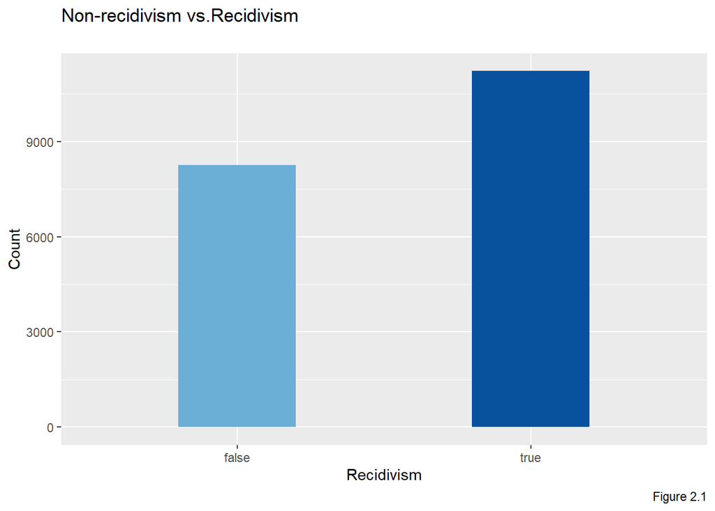

## 2.1 Categorical Variables

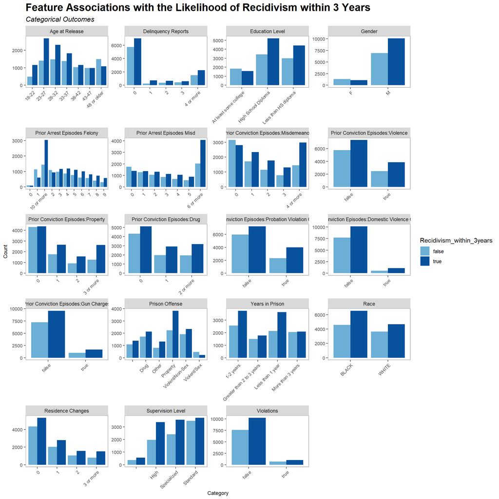

## 2.2 Chi square

|  | Degrees of Freedom | Chi-Squared | P-Value |
| --- | --- | --- | --- |
| Gender | 1 | 164.546376 | 0.0000000 |
| Race | 1 | 14.355647 | 0.0001513 |
| Age at Release | 6 | 554.953064 | 0.0000000 |
| Supervision Level First | 3 | 182.961517 | 0.0000000 |
| Education Level | 2 | 231.066410 | 0.0000000 |
| Prison Offense | 5 | 297.917277 | 0.0000000 |
| Years in Prison | 3 | 181.328488 | 0.0000000 |
| Violations | 1 | 1.549674 | 0.2131836 |

Table 1: Chi-square Test Results for Recidivism Variables

## 2.3 Numeric Variables

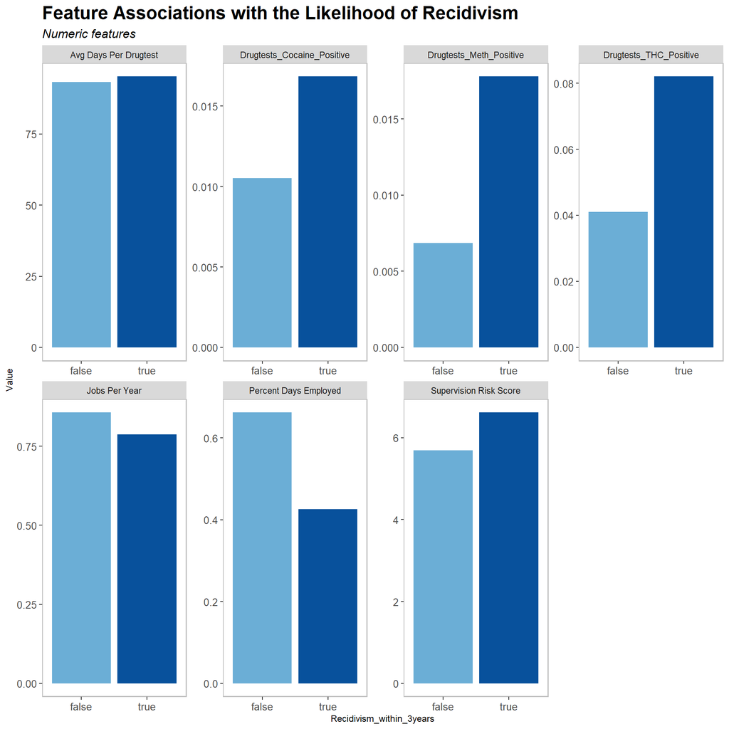

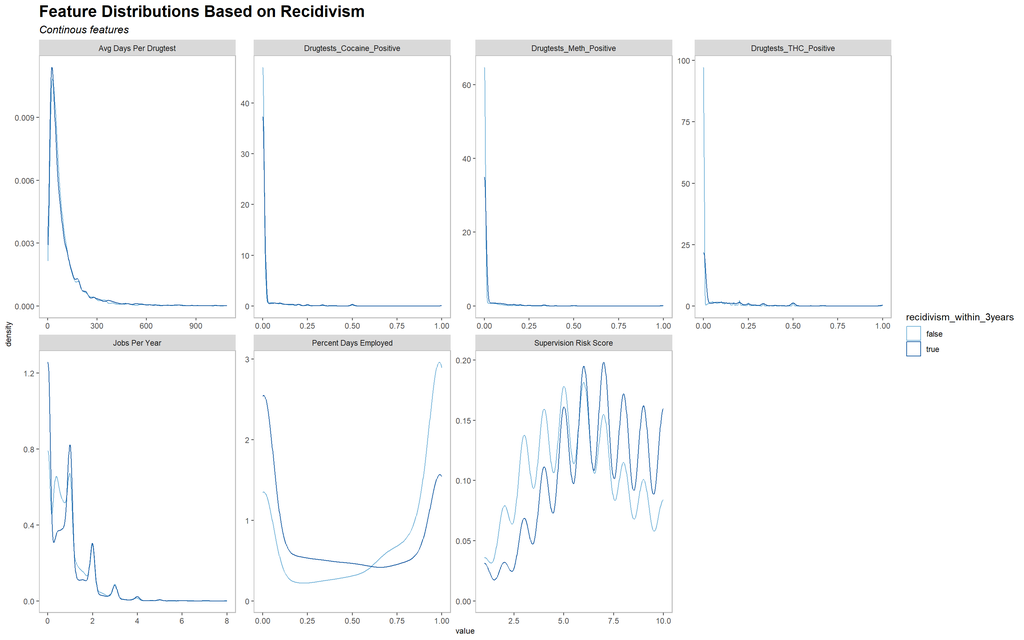

## 2.4 ANOVA TEST

| Variable | Degrees of Freedom | Sum Sq | Mean Sq | F value | P-Value |
| --- | --- | --- | --- | --- | --- |
| Supervision Risk Score | 1 | 4070.1579080 | 4070.1579080 | 739.872265 | 0.0000000 |
| Percent Days Employed | 1 | 266.0210430 | 266.0210430 | 1670.091995 | 0.0000000 |
| Jobs Per Year | 1 | 23.0516060 | 23.0516060 | 34.153569 | 0.0000000 |
| Avg Days Per Drugtest | 1 | 19094.3164729 | 19094.3164729 | 1.378441 | 0.2403812 |
| THC Positive Drugtests | 1 | 8.0005626 | 8.0005626 | 426.354437 | 0.0000000 |
| Meth Positive Drugtests | 1 | 0.5694039 | 0.5694039 | 157.323593 | 0.0000000 |
| Cocaine Positive Drugtests | 1 | 0.1898414 | 0.1898414 | 49.257991 | 0.0000000 |

Table 2: ANOVA Results for Numeric Variables

# 3 Logistic Regression

## 3.1 Feature Engineering

|  | Estimate | Std. Error | z value | p_value |
| --- | --- | --- | --- | --- |
| (Intercept) | 0.7126782 | 0.2704495 | 2.6351616 | 0.008** |
| genderM | 1.2519924 | 0.0906134 | 13.8168582 | 0*** |
| raceWHITE | 0.1757010 | 0.0472198 | 3.7209160 | 0*** |
| age_at_release23-27 | -0.2035117 | 0.0893055 | -2.2788266 | 0.023* |
| age_at_release28-32 | -0.5361357 | 0.0965223 | -5.5545259 | 0*** |
| age_at_release33-37 | -0.7526326 | 0.1039151 | -7.2427670 | 0*** |
| age_at_release38-42 | -1.0257366 | 0.1140133 | -8.9966399 | 0*** |
| age_at_release43-47 | -1.1511516 | 0.1197118 | -9.6160244 | 0*** |
| age_at_release48 or older | -1.4064175 | 0.1211012 | -11.6135689 | 0*** |
| dependents1 | 0.0744073 | 0.0587672 | 1.2661376 | 0.205 |
| dependents2 | 0.0670923 | 0.0622891 | 1.0771113 | 0.281 |
| dependents3 or more | 0.0777409 | 0.0551881 | 1.4086525 | 0.159 |
| supervision_level_firstHigh | -0.1074225 | 0.1079288 | -0.9953082 | 0.32 |
| supervision_level_firstSpecialized | -0.2369260 | 0.1145185 | -2.0688883 | 0.039* |
| supervision_level_firstStandard | -0.3100568 | 0.1007969 | -3.0760563 | 0.002** |
| education_levelHigh School Diploma | 0.1157635 | 0.0596186 | 1.9417346 | 0.052. |
| education_levelLess than HS diploma | -0.0767769 | 0.0618991 | -1.2403559 | 0.215 |
| prison_yearsGreater than 2 to 3 years | -0.2514696 | 0.0624169 | -4.0288684 | 0*** |
| prison_yearsLess than 1 year | 0.0974542 | 0.0553751 | 1.7598921 | 0.078. |
| prison_yearsMore than 3 years | -0.0681826 | 0.0645590 | -1.0561293 | 0.291 |
| prison_offenseDrug | -0.0437575 | 0.0750828 | -0.5827904 | 0.56 |
| prison_offenseOther | 0.0970331 | 0.0869373 | 1.1161272 | 0.264 |
| prison_offenseProperty | 0.0762811 | 0.0775578 | 0.9835378 | 0.325 |
| prison_offenseViolent/Non-Sex | 0.0542936 | 0.0829007 | 0.6549241 | 0.513 |
| prison_offenseViolent/Sex | -0.2986716 | 0.1399852 | -2.1335933 | 0.033* |
| violationstrue | 0.3413735 | 0.0826555 | 4.1300758 | 0*** |
| supervision_risk_score_first | 0.0257987 | 0.0131348 | 1.9641540 | 0.05* |
| percent_days_employed | -1.9720022 | 0.0671005 | -29.3887919 | 0*** |
| jobs_per_year | 0.4787924 | 0.0338244 | 14.1552458 | 0*** |
| drugtests_thc_positive | 0.8571145 | 0.1831965 | 4.6786617 | 0*** |
| drugtests_cocaine_positive | 0.9720569 | 0.3566397 | 2.7255994 | 0.006** |
| drugtests_meth_positive | 3.2651959 | 0.5540167 | 5.8936777 | 0*** |
| gang_affiliatedfalse | -0.8349347 | 0.0690981 | -12.0833202 | 0*** |
| prior_arrest_episodes_felony1 | -1.1443050 | 0.2270044 | -5.0408923 | 0*** |
| prior_arrest_episodes_felony10 or more | 0.0788588 | 0.2397854 | 0.3288724 | 0.742 |
| prior_arrest_episodes_felony2 | -0.8420190 | 0.2264420 | -3.7184757 | 0*** |
| prior_arrest_episodes_felony3 | -0.6068374 | 0.2281703 | -2.6595809 | 0.008** |
| prior_arrest_episodes_felony4 | -0.3838915 | 0.2306083 | -1.6646910 | 0.096. |
| prior_arrest_episodes_felony5 | -0.4621874 | 0.2330948 | -1.9828296 | 0.047* |
| prior_arrest_episodes_felony6 | -0.3430947 | 0.2359896 | -1.4538556 | 0.146 |
| prior_arrest_episodes_felony7 | -0.4287147 | 0.2387863 | -1.7953904 | 0.073. |
| prior_arrest_episodes_felony8 | -0.2689002 | 0.2436766 | -1.1035127 | 0.27 |
| prior_arrest_episodes_felony9 | -0.1115054 | 0.2498422 | -0.4463034 | 0.655 |
| prior_arrest_episodes_misd1 | 0.1444300 | 0.0794710 | 1.8173919 | 0.069. |
| prior_arrest_episodes_misd2 | 0.2340127 | 0.0879175 | 2.6617292 | 0.008** |
| prior_arrest_episodes_misd3 | 0.1925148 | 0.0961888 | 2.0014274 | 0.045* |
| prior_arrest_episodes_misd4 | 0.4443480 | 0.1022946 | 4.3438095 | 0*** |
| prior_arrest_episodes_misd5 | 0.3366866 | 0.1095373 | 3.0737157 | 0.002** |
| prior_arrest_episodes_misd6 or more | 0.5429037 | 0.1009579 | 5.3775228 | 0*** |
| prior_arrest_episodes_property1 | 0.1694564 | 0.0675417 | 2.5089165 | 0.012* |
| prior_arrest_episodes_property2 | 0.0798497 | 0.0824422 | 0.9685538 | 0.333 |
| prior_arrest_episodes_property3 | 0.1173772 | 0.0976368 | 1.2021818 | 0.229 |
| prior_arrest_episodes_property4 | 0.2293341 | 0.1135703 | 2.0193136 | 0.043* |
| prior_arrest_episodes_property5 or more | 0.2083082 | 0.1170971 | 1.7789352 | 0.075. |
| prior_conviction_episodes_6true | 0.0436694 | 0.0841370 | 0.5190278 | 0.604 |
| prior_conviction_episodes_5true | -0.0963547 | 0.0531789 | -1.8118977 | 0.07. |
| prior_conviction_episodes_41 | 0.1367272 | 0.0558039 | 2.4501352 | 0.014* |
| prior_conviction_episodes_42 or more | 0.0537114 | 0.0648643 | 0.8280575 | 0.408 |
| prior_conviction_episodes_31 | 0.0646623 | 0.0634722 | 1.0187496 | 0.308 |
| prior_conviction_episodes_32 | -0.0210733 | 0.0850019 | -0.2479155 | 0.804 |
| prior_conviction_episodes_33 or more | 0.1846194 | 0.0996270 | 1.8531057 | 0.064. |
| prior_conviction_episodes_2true | -0.0003465 | 0.0544026 | -0.0063686 | 0.995 |
| prior_conviction_episodes_11 | 0.1280804 | 0.0670377 | 1.9105729 | 0.056. |
| prior_conviction_episodes_12 | 0.1818480 | 0.0813535 | 2.2352812 | 0.025* |
| prior_conviction_episodes_13 | 0.1862000 | 0.0952356 | 1.9551506 | 0.051. |
| prior_conviction_episodes_14 or more | 0.2701187 | 0.0974837 | 2.7709105 | 0.006** |
| prior_revocations_probationtrue | -0.0834686 | 0.0597131 | -1.3978268 | 0.162 |
| prior_revocations_paroletrue | 0.4337385 | 0.0779790 | 5.5622465 | 0*** |
| delinquency_reports1 | 0.6389666 | 0.1116804 | 5.7213853 | 0*** |
| delinquency_reports2 | -0.0086961 | 0.0968055 | -0.0898302 | 0.928 |
| delinquency_reports3 | -0.3688412 | 0.0965200 | -3.8213968 | 0*** |
| delinquency_reports4 or more | -0.5337437 | 0.0617214 | -8.6476246 | 0*** |
| residence_changes1 | 0.0824639 | 0.0508303 | 1.6223378 | 0.105 |
| residence_changes2 | 0.1667080 | 0.0637938 | 2.6132315 | 0.009** |
| residence_changes3 or more | 0.3901620 | 0.0701428 | 5.5623980 | 0*** |
| violations_instructiontrue | 0.1371471 | 0.0578473 | 2.3708448 | 0.018* |

Table 3

```
## fitting null model for pseudo-r2
```

```
##           llh       llhNull            G2      McFadden          r2ML
## -7010.5296537 -8640.9961332  3260.9329590     0.1886896     0.2270469
##          r2CU
##     0.3049303
```

```
##    Outcome     Probs
## 1        0 0.4171032
## 2        1 0.6347926
## 7        1 0.6640752
## 8        0 0.4864873
## 10       1 0.9020390
## 14       1 0.7007818
```

Visually we now can begin comparing the predictions of recidivism. A negative or 0 value means that there is no recidivism, while a positive or 1 value means that there is recidivism. Strong models will have a peak closer to 0 for the negatives (no recidivism), and a peak closer to 1 for the positives (recidivism). In the following graph we can see that our model is better at prediciting the positives rather than the negatives.

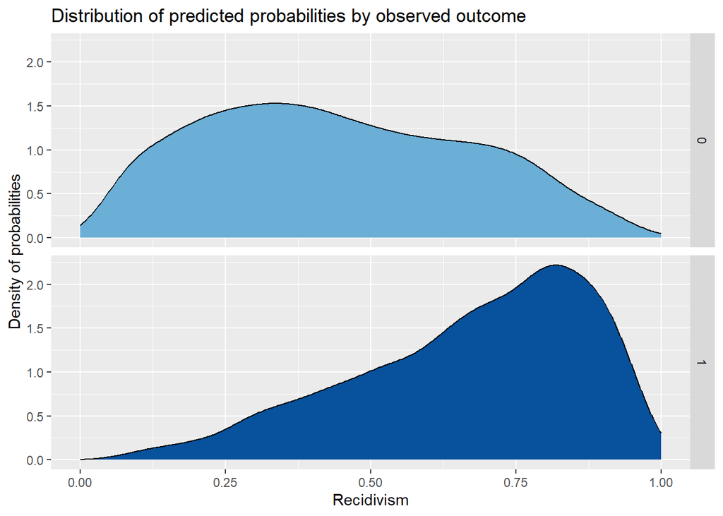

## 3.2 ROC Curve

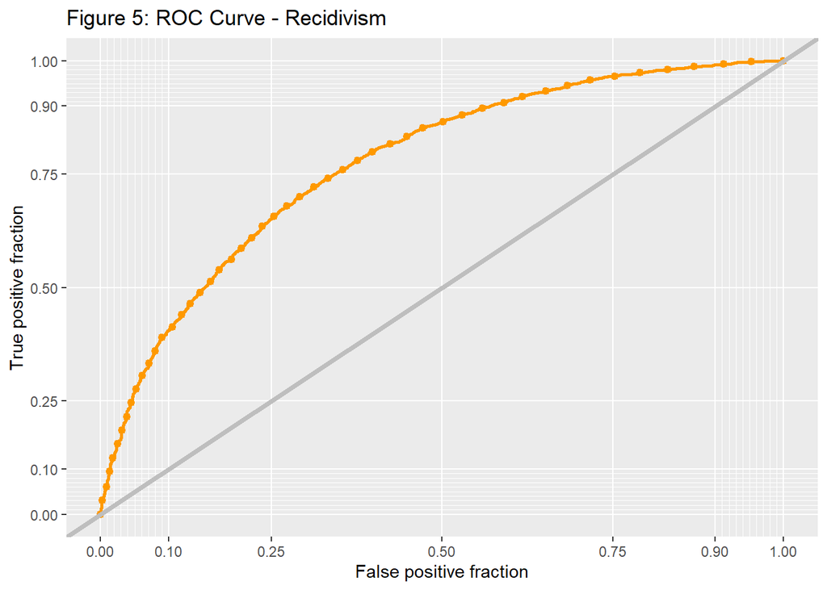

```
## Area under the curve: 0.7747
```

## 3.3 Confusion Matrix

```
## Confusion Matrix and Statistics
##
##           Reference
## Prediction    0    1
##          0  900  214
##          1 1949 3753
##
##                Accuracy : 0.6827
##                  95% CI : (0.6715, 0.6937)
##     No Information Rate : 0.582
##     P-Value [Acc > NIR] : < 0.00000000000000022
##
##                   Kappa : 0.2865
##
##  Mcnemar's Test P-Value : < 0.00000000000000022
##
##             Sensitivity : 0.9461
##             Specificity : 0.3159
##          Pos Pred Value : 0.6582
##          Neg Pred Value : 0.8079
##              Prevalence : 0.5820
##          Detection Rate : 0.5506
##    Detection Prevalence : 0.8366
##       Balanced Accuracy : 0.6310
##
##        'Positive' Class : 1
##
```

## 3.4 Cross Validation

```
## Generalized Linear Model
##
## 19478 samples
##    30 predictor
##     2 classes: 'false', 'true'
##
## No pre-processing
## Resampling: Cross-Validated (100 fold)
## Summary of sample sizes: 19284, 19283, 19282, 19283, 19283, 19284, ...
## Resampling results:
##
##   ROC        Sens       Spec
##   0.7757784  0.6004452  0.7954978
```

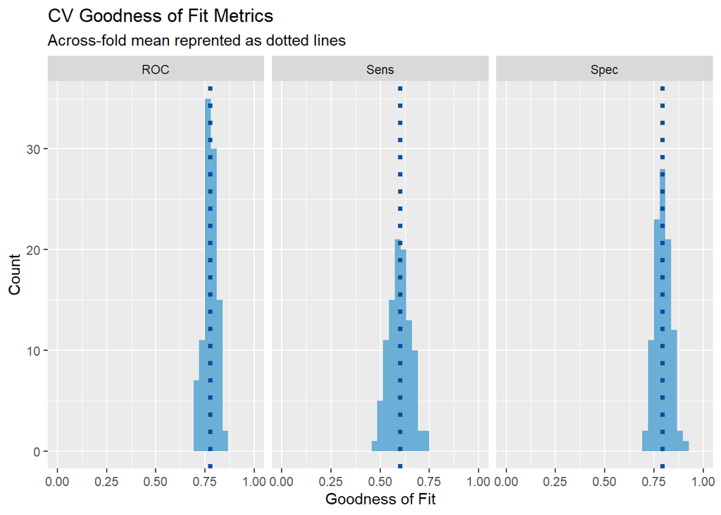

# 4 Generalizability

This section contrasts observed and predicted recidivism rates given the 50% threshold, focusing on the implications for racial and racial-gender fairness.

## 4.1 Racial Fairness

The following chart illustrates a higher recidivism rate for Black individuals compared to White individuals, there is a higher recidivism rate among black individuals than white individuals.

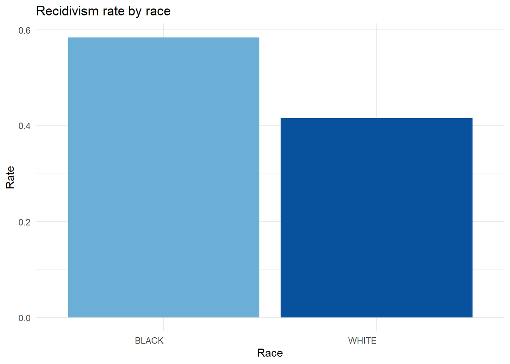

Furthermore, when comparing observed and predicted recidivism rates by race, the model appears to predict higher rates for both Black and White groups, with a slightly larger disparity for Black individuals, which means the recidivism among black individuals are over-predict.

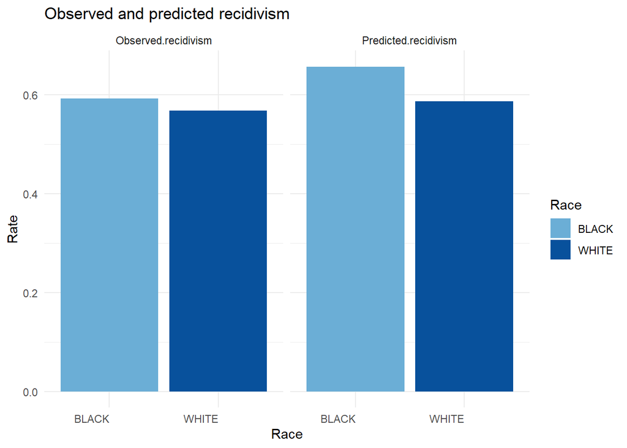

**False Positive**:For Black individuals, the model has a higher false positive rate, suggesting a tendency to over-predict recidivism.

**False Negative**: The higher false negative rate for White individuals indicates a tendency to under-predict recidivism.

In the meantime the model performs better in correctly identifying White individuals who will not recidivate and predicting recidivism for Black individuals.

**Thus, for black individuals, the model has risk incorrectly predict the non-recidivism while perform better in predicting recidivism; and the situation is reversed for white individuals.**

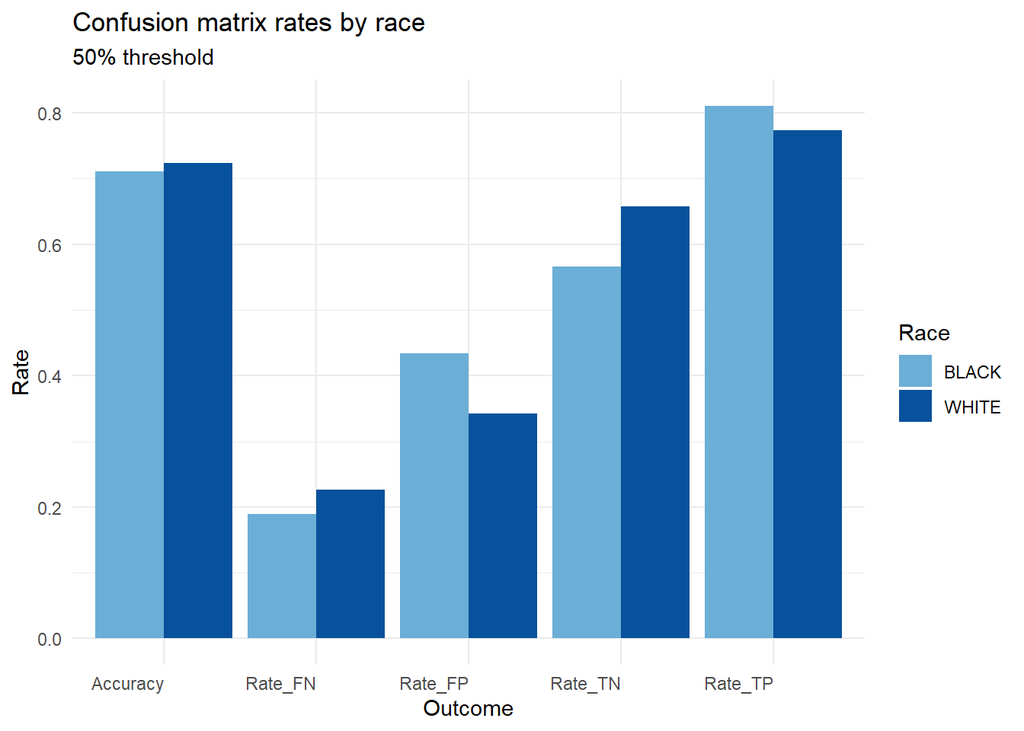

The following ROC curves compare the model’s true positive rate and false positive rate across races. Ideally, the curves should be similar, indicating the model performs equally well for each race. Differences in the curves or AUC values could indicate the model is more or less effective for white over black, suggesting a potential racial bias but not significant.

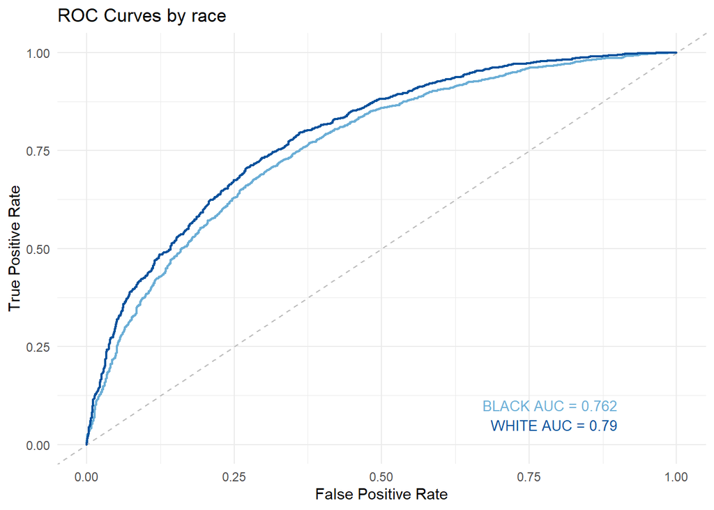

## 4.2 Racial-Gender Fairness

The generalizability of the model is further examined by considering not only race but also the intersection of race and gender. The fairness across these intersectional groups is critical, as it may reveal subtle biases not apparent when examining race alone.

From the following chart we can find that the group of black male has the highest frequency of recidivism, while the lowest recidivism frequency appears to the group of black female.

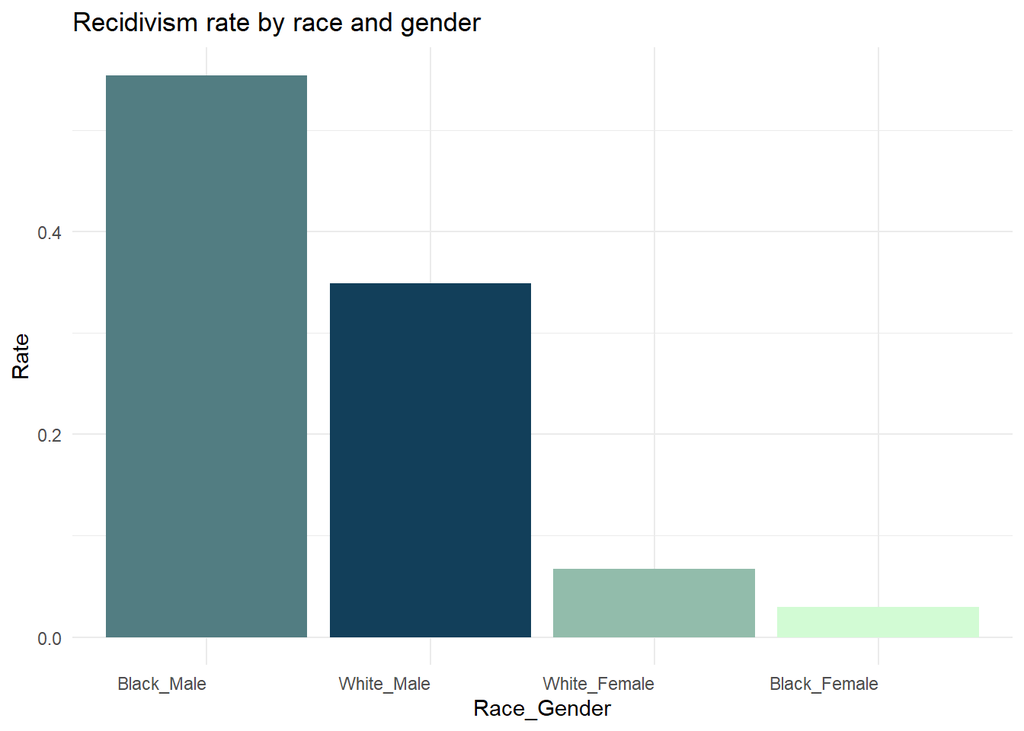

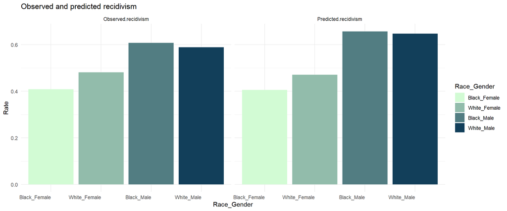

In the following breakdown plot by confusion matrix, the model exhibits a similar accuracy for the 4 groups with a relatively lower accuracy rate for while female, which means the model would preform worse in predicting white female’s recidivism.

**False Positive**:For male, especially black male, the model has a higher false positive rate, suggesting a tendency to over-predict recidivism.

**False Negative**: The higher false negative rate for black and white female indicates a tendency to under-predict recidivism.

In the meantime the model performs better in correctly identifying females especially black females who will not recidivate and predicting recidivism for males.

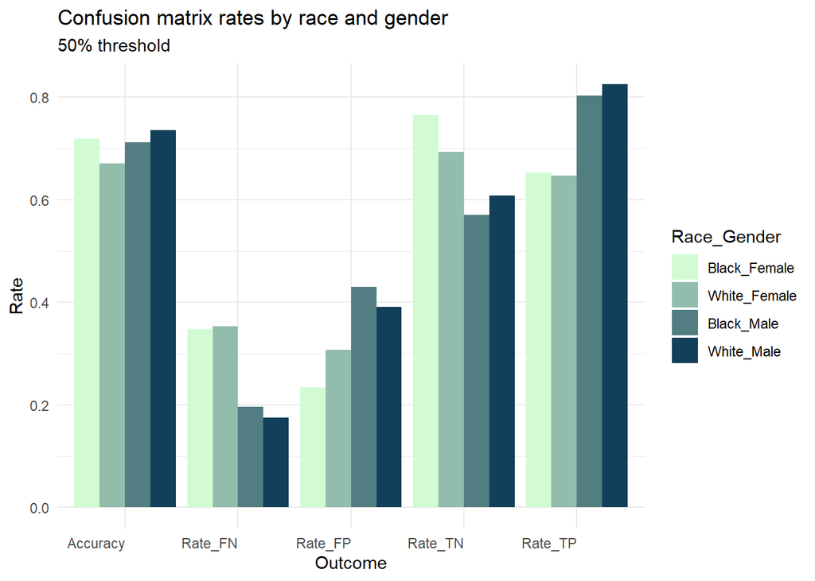

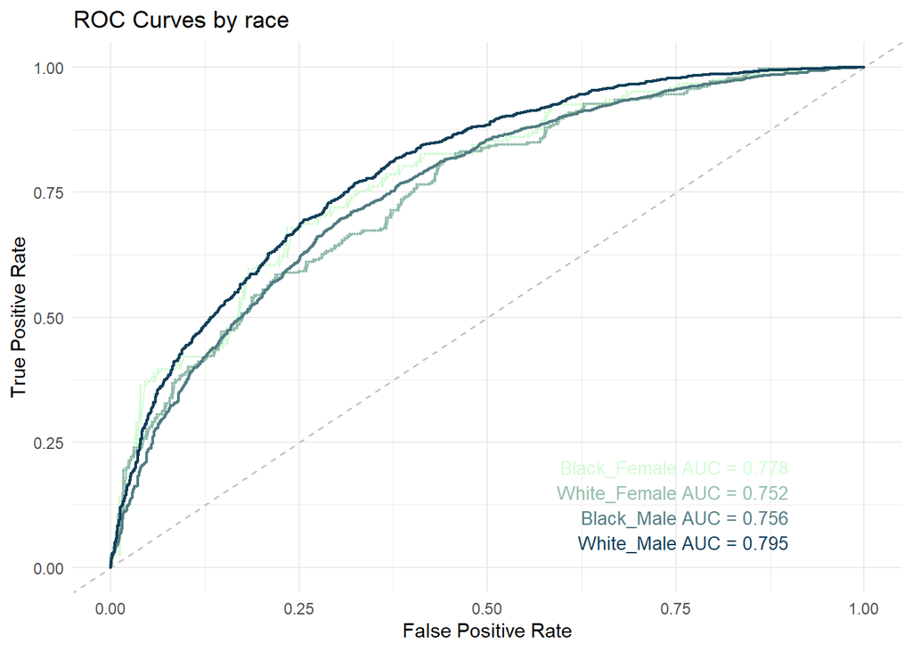

# 5 Cost-Benefit Analysis

**Costs of Incarceration:**

Cost of keeping someone in prison per year: $50,000.

*This cost includes expenses for security, food, health care, and administration.*

**Costs of Recidivism:**

Arrest costs: $2,000 per arrest.

Trial and court costs: $15,000 per case.

Probation or parole supervision costs: $4,000 per year.

Average number of arrests for recidivists: 2.

Probability of going to trial if arrested: 0.5.

**Economic Benefits of Avoiding Incarceration:**

Estimated value of productive work if not incarcerated: $30,000 per year.

Cost savings from reduced prison population: $10,000 per year *(due to economies of scale, reduced need for facilities, etc.)*.

With these assumptions, we frame the cost-benefit calculations for each possible outcome of the prediction model:

**True Negative (TN): Individuals correctly predicted not to recidivate and thus not incarcerated.**

Benefit: $50,000 *(cost of incarceration avoided)* + $30,000 *(value of productive work)* + $10,000 *(cost savings)* = $90,000.

**True Positive (TP): Individuals correctly predicted to recidivate and thus incarcerated.**

Cost: $50,000 *(cost of keeping someone in prison)* - $30,000 *(value of productive work not realized)* = $20,000 net cost.

**False Positive (FP): Individuals incorrectly predicted to recidivate and thus incarcerated.**

Cost: $50,000 *(unnecessary cost of incarceration)* + $30,000 *(loss of productive work)* + $10,000 *(cost savings not realized)* = $90,000.

Cost/Benefit Analysis

| Variable | Count | Revenue | Description |
| --- | --- | --- | --- |
| True_Negative | 900 | 81000 | We correctly predicted no recidivism |
| True_Positive | 3753 | -75060 | We correctly predicted a recidivism |
| False_Negative | 214 | -5992 | We predicted no recidivism but the crime did recidivate |
| False_Positive | 1949 | -175410 | We predicted a recidivism but the crime did not recidivate |

The cost-benefit analysis table and corresponding graphs provide a stark visualization of the economic impact of recidivism predictions at varying thresholds. In the analysis, the number of true negatives and true positives dominates the count of outcomes, indicating a predictive model reasonably attuned to actual outcomes.

With true negatives, we witness a substantial benefit, as these cases represent individuals correctly predicted not to recidivate, saving the system the cost of incarceration and the associated lost productivity. Conversely, the costliest scenario emerges from false positives.

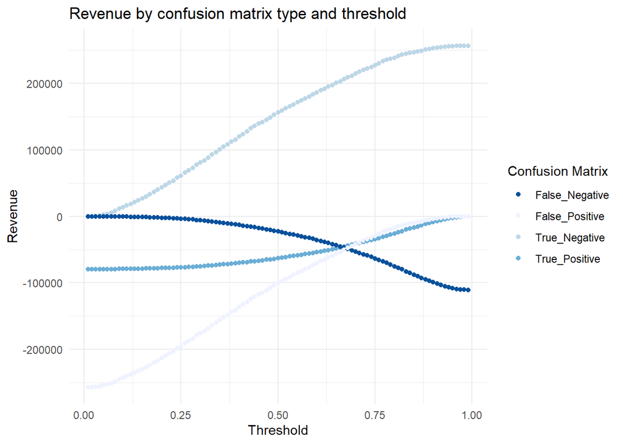

As seen in the above and below fugures, revenue begins to normalize or flatten out at 0.75 This means that if as a department we want to maximize our budget, we should only allocate to those in the thresholds between .75 to 1.

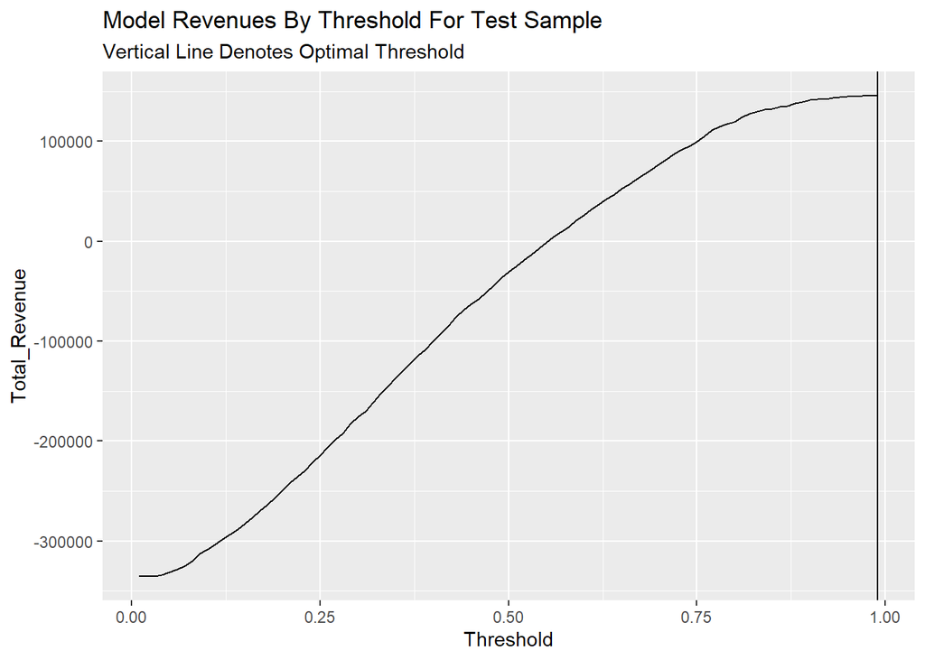

# 6 Conclusion

In conclusion, the analysis shows a model that is adept at identifying individuals who are likely to recidivate, specifically benefiting community safety and economic planning. It effectively captures the true positive rates—those who are likely to benefit from interventions—underscoring its utility from a social stability perspective.

However, the model struggles with false positives, which could lead to unnecessary social and economic burdens, especially among certain demographic groups. The disproportionate impact on Black Males, in particular, highlights an area for immediate review and adjustment.

For a more balanced approach that maximizes the model’s strengths and minimizes its weaknesses, it is essential to consider:

1. Reevaluating the model parameters and integrating a broader range of data points, such as spatial characteristics, to refine its predictive accuracy.
2. Implementing strategies to mitigate the potential economic impacts of the model’s current limitations, such as targeted outreach and support for those wrongly identified as high risk for recidivism.
3. Ensuring constant monitoring and adjustment of the model to adapt to dynamic social factors and economic conditions, thus ensuring its continued relevance and fairness.

Such steps will ensure that the model does not just serve as a predictive tool but also as a catalyst for constructive interventions, aligning with the overarching goals of community development and economic sustainability.